# Temp Access Abuse Analysis

# 3 Data Analysis

Looking at the most recent eight terms, there are indications of a seasonal trend with a spike in potential abusive behavior in spring, before returning to lower levels in the fall and winter terms. This is likely a function of fewer students/courses in the spring vs other terms, but further exploration could reveal other causes.

fig 6

| Term | 50% Percentile | 60% Percentile | 70% Percentile | 80% Percentile | 90% Percentile | 95% Percentile |
| --- | --- | --- | --- | --- | --- | --- |
| Wi_15 | 0% | 0% | 9.09% | 16.7% | 33.3% | 50% |
| Sp_15 | 11.1% | 20% | 33.3% | 50% | 50% | 90% |
| Fa_15 | 0% | 0% | 10% | 16.7% | 33.3% | 50% |
| Wi_16 | 0% | 0% | 7.14% | 14.3% | 25% | 50% |
| Sp_16 | 0% | 10% | 18.8% | 30% | 50% | 55.6% |
| Fa_16 | 0% | 0% | 8.33% | 15% | 27.3% | 50% |
| Wi_17 | 0% | 0% | 8.33% | 15.4% | 28.6% | 50% |
| Sp_17 | 0% | 11.8% | 20% | 31.8% | 50% | 66.7% |

Finally, the distribution of total completed activities and temp access period completed activities - segmented by Paying and Non-Paying students - can be seen in figures 7 & 8. As would be expected, Paying students have a higher total completion rate over the total course length. Figure 8 shows that in the temp access period, once the percentage moves past 50% the Non-Paying students outnumber Paying students consistently until 100% is reached. While the volume is low, it is an established trend, and this is the are where the potential loss will be judged.

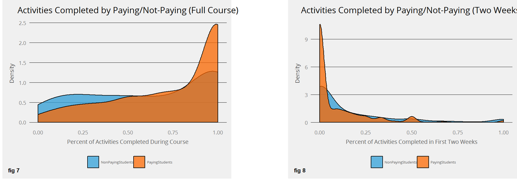

# 4 Conclusions

There is a clearly noticeable difference in behavior of Paying and Not-Paying students with regards to activity completion. There is also some noise in the data that is not accounted for in this analysis (particularly course with outliers in length, number of students, and total activities) - but most likely would not have a significant impact on the outcome.

Given the potential loss of revenue, an evaluation of the temp access period process is recommended. Additionally, rerunning this analysis when the 2017 Fall term is completed to have a full three year window for all term seasons is recommended.